# Hotel Booking Demand

## 目录

简介  
数据整理  
探索性数据分析  
结论

## 简介

分析步骤分为以下几步：  
1.提出问题  
2.导入数据  
3.数据清洗  
4.数据分析及可视化  
5.形成数据分析报告

数据来源：[Hotel booking demand](https://www.kaggle.com/jessemostipak/hotel-booking-demand)

### 1.提出问题

1. 酒店运营情况怎么样（取消率，价格走向，人流量，客源）
2. 影响取消预定的因素
3. 细分市场的预定情况

### 2. 导入数据

```python
import numpy as np
import pandas as pd
import matplotlib.pyplot as plt
% matplotlib inline
import seaborn as sns
import json
```

```
UsageError: Line magic function `%` not found.
```

```python
df = pd.read_csv('hotel_bookings.csv')
df.head()
```

|  | hotel | is_canceled | lead_time | arrival_date_year | arrival_date_month | arrival_date_week_number | arrival_date_day_of_month | stays_in_weekend_nights | stays_in_week_nights | adults | ... | deposit_type | agent | company | days_in_waiting_list | customer_type | adr | required_car_parking_spaces | total_of_special_requests | reservation_status | reservation_status_date |
| --- | --- | --- | --- | --- | --- | --- | --- | --- | --- | --- | --- | --- | --- | --- | --- | --- | --- | --- | --- | --- | --- |
| 0 | Resort Hotel | 0 | 342 | 2015 | July | 27 | 1 | 0 | 0 | 2 | ... | No Deposit | NaN | NaN | 0 | Transient | 0.0 | 0 | 0 | Check-Out | 2015-07-01 |
| 1 | Resort Hotel | 0 | 737 | 2015 | July | 27 | 1 | 0 | 0 | 2 | ... | No Deposit | NaN | NaN | 0 | Transient | 0.0 | 0 | 0 | Check-Out | 2015-07-01 |
| 2 | Resort Hotel | 0 | 7 | 2015 | July | 27 | 1 | 0 | 1 | 1 | ... | No Deposit | NaN | NaN | 0 | Transient | 75.0 | 0 | 0 | Check-Out | 2015-07-02 |
| 3 | Resort Hotel | 0 | 13 | 2015 | July | 27 | 1 | 0 | 1 | 1 | ... | No Deposit | 304.0 | NaN | 0 | Transient | 75.0 | 0 | 0 | Check-Out | 2015-07-02 |
| 4 | Resort Hotel | 0 | 14 | 2015 | July | 27 | 1 | 0 | 2 | 2 | ... | No Deposit | 240.0 | NaN | 0 | Transient | 98.0 | 0 | 1 | Check-Out | 2015-07-03 |

5 rows × 32 columns

### 3. 清理数据

**清理缺失值**

```python
df.isnull().sum()[df.isnull().sum()!=0]
```

```
children         4
country        488
agent        16340
company     112593
dtype: int64
```

以上缺失值用0或者众数替代

```python
df['agent'].fillna(0, inplace = True)
df['children'].fillna(df['children'].mode()[0], inplace = True)
df['country'].fillna(df['country'].mode()[0], inplace = True)
df.drop('company', axis=1, inplace = True)
```

**处理异常值**

修改数据类型

```python
df.info()
```

```
<class 'pandas.core.frame.DataFrame'>
RangeIndex: 119390 entries, 0 to 119389
Data columns (total 31 columns):
hotel                             119390 non-null object
is_canceled                       119390 non-null int64
lead_time                         119390 non-null int64
arrival_date_year                 119390 non-null int64
arrival_date_month                119390 non-null object
arrival_date_week_number          119390 non-null int64
arrival_date_day_of_month         119390 non-null int64
stays_in_weekend_nights           119390 non-null int64
stays_in_week_nights              119390 non-null int64
adults                            119390 non-null int64
children                          119390 non-null float64
babies                            119390 non-null int64
meal                              119390 non-null object
country                           119390 non-null object
market_segment                    119390 non-null object
distribution_channel              119390 non-null object
is_repeated_guest                 119390 non-null int64
previous_cancellations            119390 non-null int64
previous_bookings_not_canceled    119390 non-null int64
reserved_room_type                119390 non-null object
assigned_room_type                119390 non-null object
booking_changes                   119390 non-null int64
deposit_type                      119390 non-null object
agent                             119390 non-null float64
days_in_waiting_list              119390 non-null int64
customer_type                     119390 non-null object
adr                               119390 non-null float64
required_car_parking_spaces       119390 non-null int64
total_of_special_requests         119390 non-null int64
reservation_status                119390 non-null object
reservation_status_date           119390 non-null object
dtypes: float64(3), int64(16), object(12)
memory usage: 28.2+ MB
```

```python
df['children'] = df['children'].astype(int)
df['agent'] = df['agent'].astype(int)
df['meal'].replace('Undefined', 'SC', inplace = True)
```

去除客人为0的空值

```python
zero_guest = list(df['adults'] + df['children'] + df['babies'] == 0)
df.drop(df.index[zero_guest], inplace = True)
df.info()
```

```
<class 'pandas.core.frame.DataFrame'>
Int64Index: 119210 entries, 0 to 119389
Data columns (total 31 columns):
hotel                             119210 non-null object
is_canceled                       119210 non-null int64
lead_time                         119210 non-null int64
arrival_date_year                 119210 non-null int64
arrival_date_month                119210 non-null object
arrival_date_week_number          119210 non-null int64
arrival_date_day_of_month         119210 non-null int64
stays_in_weekend_nights           119210 non-null int64
stays_in_week_nights              119210 non-null int64
adults                            119210 non-null int64
children                          119210 non-null int64
babies                            119210 non-null int64
meal                              119210 non-null object
country                           119210 non-null object
market_segment                    119210 non-null object
distribution_channel              119210 non-null object
is_repeated_guest                 119210 non-null int64
previous_cancellations            119210 non-null int64
previous_bookings_not_canceled    119210 non-null int64
reserved_room_type                119210 non-null object
assigned_room_type                119210 non-null object
booking_changes                   119210 non-null int64
deposit_type                      119210 non-null object
agent                             119210 non-null int64
days_in_waiting_list              119210 non-null int64
customer_type                     119210 non-null object
adr                               119210 non-null float64
required_car_parking_spaces       119210 non-null int64
total_of_special_requests         119210 non-null int64
reservation_status                119210 non-null object
reservation_status_date           119210 non-null object
dtypes: float64(1), int64(18), object(12)
memory usage: 29.1+ MB
```

### 4.数据分析及可视化

**4.1 入住率和取消率**

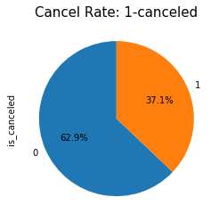

```python
cancel = df.is_canceled.value_counts()
cancel.plot(kind = 'pie', autopct='%1.1f%%', startangle=90)
plt.title('Cancel Rate: 1-canceled', fontsize = 15)
```

```python
df_rh_book = df[df['hotel']=='Resort Hotel'].groupby('is_canceled').hotel.count()[0]
df_rh_cancel = df[df['hotel']=='Resort Hotel'].groupby('is_canceled').hotel.count()[1]
df_ch_book = df[df['hotel']=='City Hotel'].groupby('is_canceled').hotel.count()[0]
df_ch_cancel = df[df['hotel']=='City Hotel'].groupby('is_canceled').hotel.count()[1]
```

```python
df_rh_book, df_ch_book,df_rh_cancel,  df_ch_cancel
```

```
(28927, 46084, 11120, 33079)
```

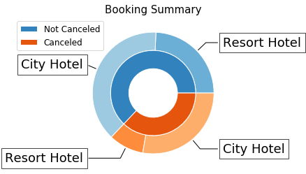

```python
fig, ax = plt.subplots()

size = 0.3
vals = np.array([[df_rh_book, df_ch_book], [df_rh_cancel, df_ch_cancel]])

cmap = plt.get_cmap("tab20c")
outer_colors = cmap(np.arange(3)*4)
inner_colors = cmap(np.array([1, 2, 5, 6]))

wedges, texts = ax.pie(vals.flatten(), radius=1, colors=inner_colors,
       wedgeprops=dict(width=size, edgecolor='w'))
wedges2, texts2 = ax.pie(vals.sum(axis=1), radius=1-size, colors=outer_colors,
       wedgeprops=dict(width=size, edgecolor='w'))

bbox_props = dict(boxstyle="square,pad=0.3", fc="w", ec="k", lw=0.72)
kw = dict(arrowprops=dict(arrowstyle="-", color="k"), bbox=bbox_props, zorder=3, va="center")

for i, p in enumerate(wedges):
    text = 'Resort Hotel', 'City Hotel', 'Resort Hotel', 'City Hotel'
    ang = (p.theta2 - p.theta1)/2. + p.theta1
    y = np.sin(np.deg2rad(ang))
    x = np.cos(np.deg2rad(ang))
    horizontalalignment = {-1: "right", 1: "left"}[int(np.sign(x))]
    connectionstyle = "angle,angleA=0,angleB={}".format(ang)
    kw["arrowprops"].update({"connectionstyle": connectionstyle})
    plt.annotate(text[i], xy=(x, y), xytext=(1.15*np.sign(x), 1.2*y),
                horizontalalignment=horizontalalignment, **kw, fontsize=18)


plt.legend(wedges2, ["Not Canceled", "Canceled"], loc=1, bbox_to_anchor=(0, 0, 0.2, 1), fontsize=12)
plt.title('Booking Summary', fontsize = 15)
plt.plot()
plt.show()
```

从图中可以看到，总体的取消率为37.1%， 其中City Hotel的取消率较高

**4.2 每月人均价格**

```python
df['price_pp'] = df['adr']/(df['adults'] + df['children'])
df_price = df[df['is_canceled']==0]
df_price['arrival_date_month'].unique()
```

```
array(['July', 'August', 'September', 'October', 'November', 'December',
       'January', 'February', 'March', 'April', 'May', 'June'],
      dtype=object)
```

```python
months = ["January", "February", "March", "April", "May", "June",
          "July", "August", "September", "October", "November", "December"]
df_price['arrival_date_month'] = pd.Categorical(df_price['arrival_date_month'], categories=months, ordered=True)
```

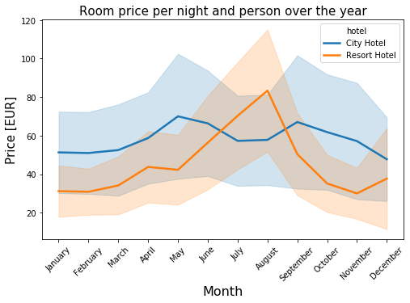

```python
import seaborn as sns
plt.figure(figsize=(8, 5))
sns.lineplot(x = "arrival_date_month", y="price_pp", data=df_price,
            hue_order = ["City Hotel", "Resort Hotel"], hue="hotel", ci="sd", size="hotel", sizes = (2.5, 2.5))
plt.title("Room price per night and person over the year", fontsize=15)
plt.xlabel("Month", fontsize=16)
plt.xticks(rotation=45)
plt.ylabel("Price [EUR]", fontsize=15)
plt.show()
```

从图中可以看出，Resort Hotel的价格在八月的时候达到顶峰，年初和年末是淡季，而City Hotel在5月和9月达到双峰，年初和年末同样是淡季。

**4.3 每月人流量**

```python
df_guest_ch = df_price[df_price['hotel'] =='City Hotel'].groupby(['arrival_date_month']).count()['hotel']
df_guest_rh = df_price[df_price['hotel'] =='Resort Hotel'].groupby(['arrival_date_month']).count()['hotel']
df_guest_ch
```

```
arrival_date_month
January      2249
February     3051
March        4049
April        4010
May          4568
June         4358
July         4770
August       5367
September    4283
October      4326
November     2676
December     2377
Name: hotel, dtype: int64
```

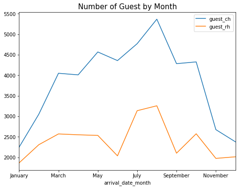

```python
df_guest = pd.concat([df_guest_ch, df_guest_rh], axis = 1)
df_guest.columns = ['guest_ch','guest_rh']
df_guest.plot(figsize = (8,6))
plt.title('Number of Guest by Month', fontsize = 15)
```

总体来看，City Hotel&Resort Hotel会在夏季迎来客流量高峰

**4.4 客源国家**

```python
df_guest = pd.concat([df_guest_ch, df_guest_rh], axis=1)
df_guest.columns = ['guest_ch','guest_rh']
```

```python
df_country = pd.DataFrame(df.loc[df['is_canceled']==0]['country'].value_counts())
df_country.columns = ['sum_country']
df_country
```

|  | sum_country |
| --- | --- |
| PRT | 21398 |
| GBR | 9668 |
| FRA | 8468 |
| ESP | 6383 |
| DEU | 6067 |
| ... | ... |
| MMR | 1 |
| MLI | 1 |
| BHR | 1 |
| PLW | 1 |
| AIA | 1 |

165 rows × 1 columns

```python
import plotly.express as px
fig = px.pie(df_country,
             values=df_country.sum_country,
             names=df_country.index,
             title="Home country of guests",
             template="seaborn")
fig.update_traces(textposition="inside", textinfo="value+percent+label")
fig.show()
```

[interactive chart not shown]

```python
guest_map = px.choropleth(df_country, locations = df_country.index, color = df_country.sum_country,
                          color_continuous_scale=px.colors.sequential.Plasma,
                          title = 'Home Country of Guests')
guest_map.show()
```

[interactive chart not shown]

从图表中可以看出客源主要来自欧洲国家，来自葡萄牙的顾客最多，占比28.5%

**4.5 影响取消的因素**

```python
cancel_corr = df.corr()['is_canceled']
cancel_corr
```

```
is_canceled                       1.000000
lead_time                         0.292876
arrival_date_year                 0.016622
arrival_date_week_number          0.008315
arrival_date_day_of_month        -0.005948
stays_in_weekend_nights          -0.001323
stays_in_week_nights              0.025542
adults                            0.058182
children                          0.004851
babies                           -0.032569
is_repeated_guest                -0.083745
previous_cancellations            0.110139
previous_bookings_not_canceled   -0.057365
booking_changes                  -0.144832
agent                            -0.046770
days_in_waiting_list              0.054301
adr                               0.046492
required_car_parking_spaces      -0.195701
total_of_special_requests        -0.234877
price_pp                          0.017808
Name: is_canceled, dtype: float64
```

结果显示，提前预定时间（lead_time）,提出要求的个数（total_of_special_requests）,需要车位（ required_car_parking_spaces）, 改变预定（booking_changes） ,以往的取消情况（previous_cancellations）对取消的影响较高。我们主要来看提前预定时间对取消预定的影响。

```python
lead_cancel_data = df.groupby('lead_time')['is_canceled'].describe()
lead_cancel_data
```

| lead_time | count | mean | std | min | 25% | 50% | 75% | max |
| --- | --- | --- | --- | --- | --- | --- | --- | --- |
| 0 | 6264.0 | 0.066571 | 0.249297 | 0.0 | 0.0 | 0.0 | 0.0 | 1.0 |
| 1 | 3445.0 | 0.092308 | 0.289502 | 0.0 | 0.0 | 0.0 | 0.0 | 1.0 |
| 2 | 2065.0 | 0.103148 | 0.304225 | 0.0 | 0.0 | 0.0 | 0.0 | 1.0 |
| 3 | 1815.0 | 0.100275 | 0.300450 | 0.0 | 0.0 | 0.0 | 0.0 | 1.0 |
| 4 | 1710.0 | 0.102339 | 0.303182 | 0.0 | 0.0 | 0.0 | 0.0 | 1.0 |
| ... | ... | ... | ... | ... | ... | ... | ... | ... |
| 622 | 17.0 | 1.000000 | 0.000000 | 1.0 | 1.0 | 1.0 | 1.0 | 1.0 |
| 626 | 30.0 | 1.000000 | 0.000000 | 1.0 | 1.0 | 1.0 | 1.0 | 1.0 |
| 629 | 17.0 | 1.000000 | 0.000000 | 1.0 | 1.0 | 1.0 | 1.0 | 1.0 |
| 709 | 1.0 | 0.000000 | NaN | 0.0 | 0.0 | 0.0 | 0.0 | 0.0 |
| 737 | 1.0 | 0.000000 | NaN | 0.0 | 0.0 | 0.0 | 0.0 | 0.0 |

479 rows × 8 columns

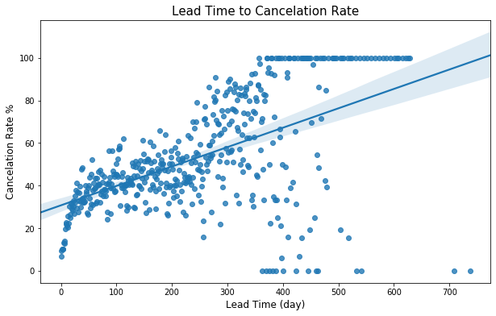

```python
y = lead_cancel_data.iloc[:,1]*100
x = list(lead_cancel_data.index)
plt.figure(figsize = (10,6))
sns.regplot(x , y)
plt.title('Lead Time to Cancelation Rate', fontsize = 15)
plt.xlabel('Lead Time (day)', fontsize = 12)
plt.ylabel('Cancelation Rate %', fontsize = 12)
```

```python
special_requests_data = df.groupby('total_of_special_requests')['is_canceled'].describe()
special_requests_data
```

| total_of_special_requests | count | mean | std | min | 25% | 50% | 75% | max |
| --- | --- | --- | --- | --- | --- | --- | --- | --- |
| 0 | 70201.0 | 0.477686 | 0.499505 | 0.0 | 0.0 | 0.0 | 1.0 | 1.0 |
| 1 | 33183.0 | 0.220474 | 0.414573 | 0.0 | 0.0 | 0.0 | 0.0 | 1.0 |
| 2 | 12952.0 | 0.221279 | 0.415124 | 0.0 | 0.0 | 0.0 | 0.0 | 1.0 |
| 3 | 2494.0 | 0.178428 | 0.382950 | 0.0 | 0.0 | 0.0 | 0.0 | 1.0 |
| 4 | 340.0 | 0.105882 | 0.308140 | 0.0 | 0.0 | 0.0 | 0.0 | 1.0 |
| 5 | 40.0 | 0.050000 | 0.220721 | 0.0 | 0.0 | 0.0 | 0.0 | 1.0 |

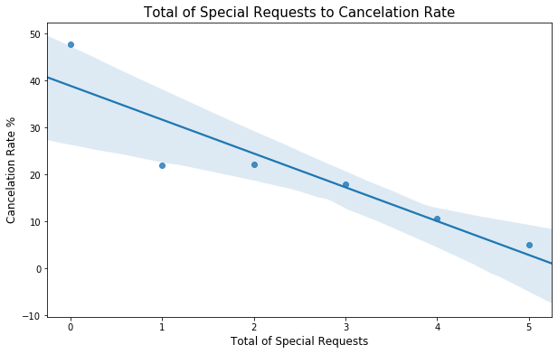

```python
y = special_requests_data.iloc[:,1]*100
x = list(special_requests_data.index)
plt.figure(figsize = (10,6))
sns.regplot(x , y)
plt.title('Total of Special Requests to Cancelation Rate', fontsize = 15)
plt.xlabel('Total of Special Requests', fontsize = 12)
plt.ylabel('Cancelation Rate %', fontsize = 12)
```

**4.6 细分市场的预定情况**

```python
#使用没有取消预定的数据
market_segment = df_price.groupby('market_segment').count()['hotel']
market_segment
```

```
market_segment
Aviation           183
Complementary      639
Corporate         4291
Direct           10648
Groups            7697
Offline TA/TO    15880
Online TA        35673
Name: hotel, dtype: int64
```

```python
market_segment = df_price.groupby('market_segment').count()['hotel']
market_segment
```

```
market_segment
Aviation           183
Complementary      639
Corporate         4291
Direct           10648
Groups            7697
Offline TA/TO    15880
Online TA        35673
Name: hotel, dtype: int64
```

```python
fig = px.pie(market_segment,
             values=market_segment.values,
            names = market_segment.index,
            title = 'Market Segment')
fig.update_traces(rotation=90, textinfo="label+percent+value")
fig.show()
```

[interactive chart not shown]

```python
df_price.groupby('market_segment').describe()['price_pp']
```

| market_segment | count | mean | std | min | 25% | 50% | 75% | max |
| --- | --- | --- | --- | --- | --- | --- | --- | --- |
| Aviation | 183.0 | 99.640328 | 20.443214 | 0.00 | 95.000 | 95.000000 | 110.00 | 193.5 |
| Complementary | 639.0 | 2.213033 | 11.710335 | 0.00 | 0.000 | 0.000000 | 0.00 | 170.0 |
| Corporate | 4291.0 | 59.012346 | 28.913861 | 0.00 | 37.000 | 60.000000 | 75.00 | 254.0 |
| Direct | 10648.0 | 59.501191 | 31.483333 | 0.00 | 39.000 | 53.333333 | 74.50 | 285.0 |
| Groups | 7697.0 | 49.446666 | 28.878974 | -3.19 | 32.000 | 42.665000 | 60.00 | 251.0 |
| Offline TA/TO | 15880.0 | 47.930689 | 24.569418 | 0.00 | 32.695 | 42.500000 | 57.50 | 510.0 |
| Online TA | 35673.0 | 57.664830 | 26.732445 | 0.00 | 41.000 | 52.500000 | 68.25 | 270.0 |

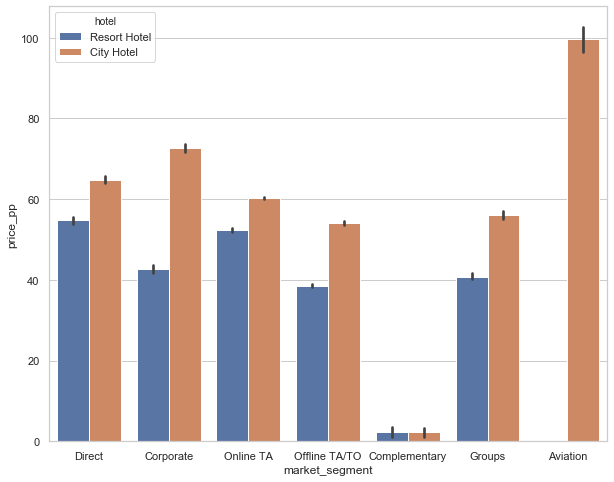

```python
plt.figure(figsize=(10, 8))
sns.set(style="whitegrid")
sns.barplot(x=df_price.market_segment, y=df_price.price_pp, hue=df_price.hotel)
```

### 5. 结论

1. 从酒店运营情况来看，酒店的取消率达到37.1%，其中City Hotel的取消率比Resort Hotel的取消率高。从价格来看，夏季是酒店的旺季，冬季是淡季。Resort Hotel在8月达到最高价格，而City Hotel在5月和9月出现双峰值。从人流量的角度看，城市酒店的客流量远高于度假酒店，在8月达到最高峰。客源国家主要来自欧洲，葡萄牙的顾客最多，占比28.5%。
2. 提前预定时间（lead_time）,提出要求的个数（total_of_special_requests）,需要车位（ required_car_parking_spaces）, 改变预定（booking_changes） ,以往的取消情况（previous_cancellations）对取消的影响较高。提前预定时间对取消预定的影响最高，成正相关，提前时间越长，取消的概率越大。
3. 从预定的细分市场来看，47.6%的顾客是从OTA网上预定平台定的酒店，其次是线下代理（21.2%）和直接预定（14.2%）。从价格角度看，通过Offline TA/TO预定的城市酒店和度假酒店价格最低。